# Penguin size comparisons

Katelyn Toigo

11/8/2020

# Part 1. T-tests

Mass comparison: male and female chinstrap penguins

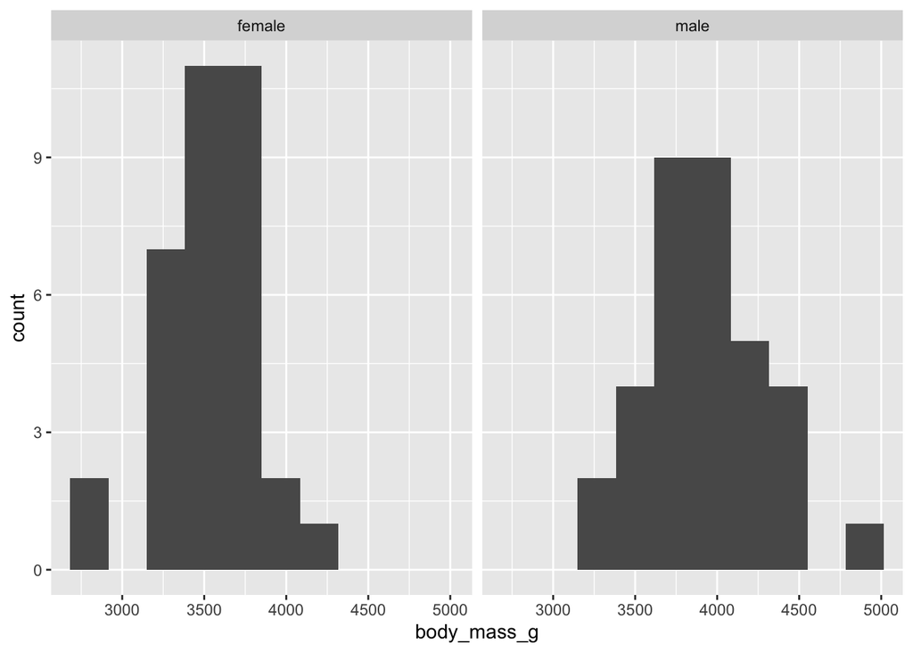

```r
chinstraps <- penguins %>%
  filter(species == "Chinstrap")

# Histograms
ggplot(data = chinstraps, aes(x=body_mass_g)) +
  geom_histogram(bins = 10)+
  facet_wrap(~sex)
```

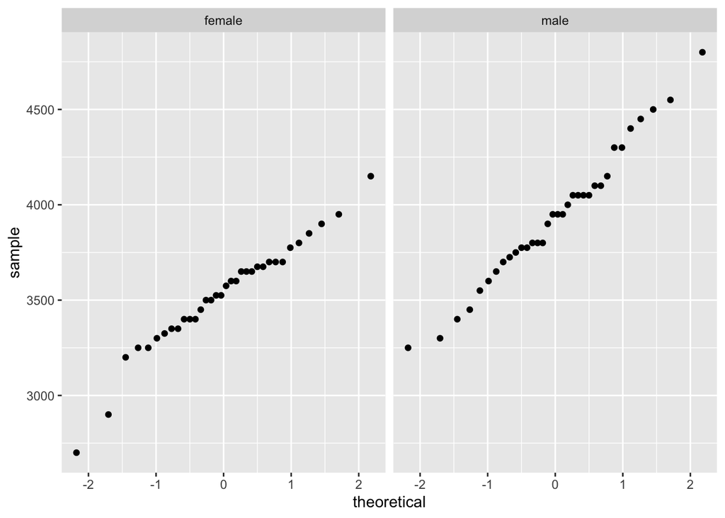

```r
## QQ plot
ggplot(data = chinstraps, aes(sample = body_mass_g)) +
  geom_qq() +
  facet_wrap(~sex)
```

```r
## Get descriptive statistics
chinstraps %>%
  group_by(sex) %>%
  summarize(
    mean_mass = mean(body_mass_g),
    median_mass = median(body_mass_g),
    sd_mass = sd(body_mass_g),
    sample_size = n())
```

```
## # A tibble: 2 x 5
##   sex    mean_mass median_mass sd_mass sample_size
##   <fct>      <dbl>       <dbl>   <dbl>       <int>
## 1 female     3527.        3550    285.          34
## 2 male       3939.        3950    362.          34
```

Get vectors of body_mass_g for female and male chinstrap penguins separately.

```r
chinstraps_f <- chinstraps %>%
  filter(sex =="female") %>%
  pull(body_mass_g)

chinstraps_m <- chinstraps %>%
  filter(sex == "male") %>%
  pull(body_mass_g)
```

### T-tests, a couple different ways

1. Is there a significant difference in body mass between male and female chinstraps penguins?

```r
chinstrap_ttest <- t.test(chinstraps_f, chinstraps_m)
chinstrap_ttest
```

```
##
##  Welch Two Sample t-test
##
## data:  chinstraps_f and chinstraps_m
## t = -5.2077, df = 62.575, p-value = 2.264e-06
## alternative hypothesis: true difference in means is not equal to 0
## 95 percent confidence interval:
##  -569.7903 -253.7391
## sample estimates:
## mean of x mean of y
##  3527.206  3938.971
```

```r
cohen.d(chinstraps_f, chinstraps_m)
```

```
##
## Cohen's d
##
## d estimate: -1.263061 (large)
## 95 percent confidence interval:
##      lower      upper
## -1.7933879 -0.7327341
```

### One sided t-test.

Not super common in env. sci.

Are male chinstrap penguins significantly larger (body mass) than female chinstrap penguins?

Insert the alternative part because it is one sided. The term could be greater or lesser, but since we are asking if males are larger and male is listed before female in the t.test() function we used “greater”. This is detrmined by which is listed first in the function.

```r
t.test(chinstraps_m, chinstraps_f, alternative = "greater")
```

```
##
##  Welch Two Sample t-test
##
## data:  chinstraps_m and chinstraps_f
## t = 5.2077, df = 62.575, p-value = 1.132e-06
## alternative hypothesis: true difference in means is greater than 0
## 95 percent confidence interval:
##  279.7552      Inf
## sample estimates:
## mean of x mean of y
##  3938.971  3527.206
```

## 1. Table of counts by species and sex

```r
penguin_counts <- penguins %>%
  count(species, sex)

penguin_counts
```

```
## # A tibble: 8 x 3
##   species   sex        n
##   <fct>     <fct>  <int>
## 1 Adelie    female    73
## 2 Adelie    male      73
## 3 Adelie    <NA>       6
## 4 Chinstrap female    34
## 5 Chinstrap male      34
## 6 Gentoo    female    58
## 7 Gentoo    male      61
## 8 Gentoo    <NA>       5
```

Create a subset of only female penguins

scale = “free” is added so that each graph can have different x and y axis

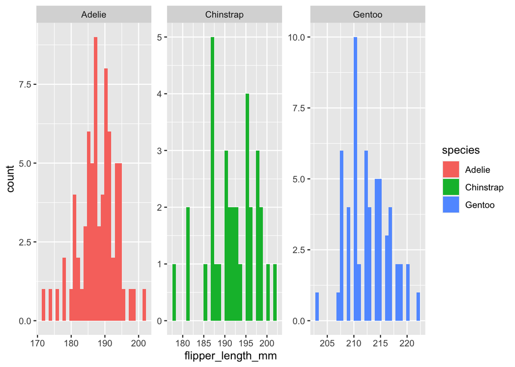

```r
penguin_f <- penguins %>%
  filter(sex == "female")

ggplot(data = penguin_f, aes(x = flipper_length_mm)) +
  geom_histogram(aes(fill = species)) +
  facet_wrap(~species, scales = "free")
```

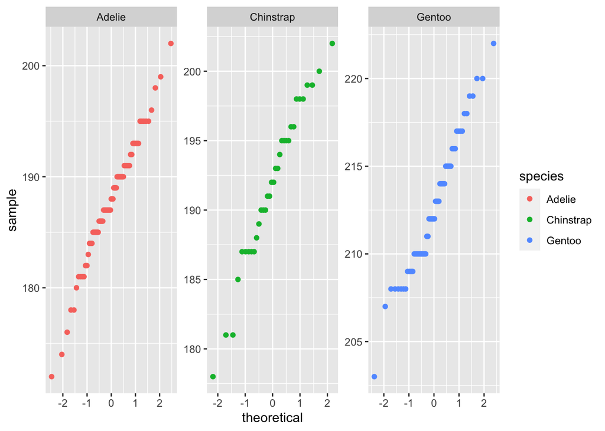

```r
ggplot(data = penguin_f, aes(sample = flipper_length_mm)) +
  geom_qq(aes(color = species)) +
  facet_wrap(~species, scales = "free")
```

### Summary statistics

Starting from penguins_f, create a summary table that groups by species, and retuns the following:

- mean of flipper length
- sd ""
- sample size
- variance `var`
- standard error = sd / sqrt(n)

```r
penguin_f_summary <- penguin_f %>%
  group_by(species) %>%
  summarize(
    mean_flipper_length = mean(flipper_length_mm),
    sd_flipper_length = sd(flipper_length_mm),
    sample_size = n(),
    se_flipper_length = sd(flipper_length_mm)/sqrt(n()),
    var_flipper_length = var(flipper_length_mm))
penguin_f_summary
```

```
## # A tibble: 3 x 6
##   species mean_flipper_le… sd_flipper_leng… sample_size se_flipper_leng…
##   <fct>              <dbl>            <dbl>       <int>            <dbl>
## 1 Adelie              188.             5.60          73            0.655
## 2 Chinst…             192.             5.75          34            0.987
## 3 Gentoo              213.             3.90          58            0.512
## # … with 1 more variable: var_flipper_length <dbl>
```

There are close enough variances to be able to run an ANOVA. The largest needs to be within 4x the smallest variance and in this case the 33.10963 variance for Chinstrap is only about 2x the variance of Gentoos at 15.19328. So these are well within the required parameters to be able to run in an ANOVA.

```r
leveneTest(flipper_length_mm ~ species, data = penguin_f)
```

```
## Levene's Test for Homogeneity of Variance (center = median)
##        Df F value  Pr(>F)
## group   2  2.9012 0.05782 .
##       162
## ---
## Signif. codes:  0 '***' 0.001 '**' 0.01 '*' 0.05 '.' 0.1 ' ' 1
```

This also backs up that the variances are close enough.

### Beeswarm plot with mean +- 1sd

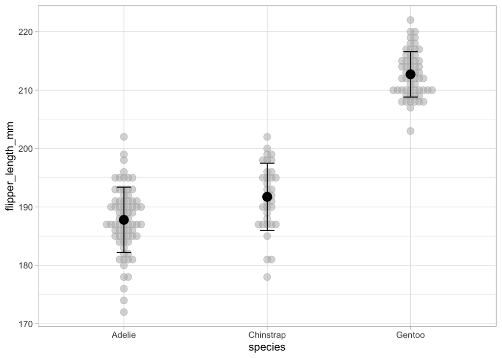

```r
ggplot() +
  geom_beeswarm(data = penguin_f,
                aes(x=species, y=flipper_length_mm),
                color = "gray70",
                size = 3,
                alpha = 0.5) +
  geom_point(data = penguin_f_summary,
             aes(x = species, y = mean_flipper_length),
             size = 4) +
  geom_errorbar(data = penguin_f_summary,
                aes(x = species,
                    ymax = mean_flipper_length + sd_flipper_length,
                    ymin = mean_flipper_length - sd_flipper_length),
                width = 0.1) +
  theme_light()
```

### One-way ANOVA

aov runs type 1 anova

usually in env. sci. you want to use type 3

```r
penguin_aov <- aov(flipper_length_mm ~ species, data = penguin_f)
summary(penguin_aov)
```

```
##              Df Sum Sq Mean Sq F value Pr(>F)
## species       2  21416   10708   411.8 <2e-16 ***
## Residuals   162   4213      26
## ---
## Signif. codes:  0 '***' 0.001 '**' 0.01 '*' 0.05 '.' 0.1 ' ' 1
```

F statistic, which here, is 411.8 is the ratio of the between group variance (sum of squares) to to the within group variance (sum of squares). This one is very large. The variance between groups is very large compared to the variance within groups. Reflected in the p-value since it is so low. Reject the null that the means for all these groups is the same.

post hoc test

```r
TukeyHSD(penguin_aov)
```

```
##   Tukey multiple comparisons of means
##     95% family-wise confidence level
##
## Fit: aov(formula = flipper_length_mm ~ species, data = penguin_f)
##
## $species
##                       diff       lwr       upr     p adj
## Chinstrap-Adelie  3.940774  1.436275  6.445272 0.0007922
## Gentoo-Adelie    24.912376 22.790647 27.034105 0.0000000
## Gentoo-Chinstrap 20.971602 18.366227 23.576977 0.0000000
```

If you have very unbalanced data (very diff sample sizes in your groups, etc.) (like you probably would in env. sci). Want to do type III anova with teh car package:

```r
penguin_lm <- lm(flipper_length_mm ~ species, data = penguin_f)
penguin_aov_t3 <- Anova(penguin_lm, type = "III")
penguin_aov_t3
```

```
## Anova Table (Type III tests)
##
## Response: flipper_length_mm
##              Sum Sq  Df  F value    Pr(>F)
## (Intercept) 2574475   1 99005.28 < 2.2e-16 ***
## species       21416   2   411.79 < 2.2e-16 ***
## Residuals      4213 162
## ---
## Signif. codes:  0 '***' 0.001 '**' 0.01 '*' 0.05 '.' 0.1 ' ' 1
```